# Problem Set 1

MOEC0021 Empirical Methods

Fenqi Guo

Wenjie Tu

Fall Semester 2020

# The Classical Linear Regression Model

## 1. Theory - Using the CLRM to Make Predictions

$$y_i=x_i'\beta+\varepsilon_i$$

- $x_i$ and $\beta$ are vectors of dimensions $K\times 1$.
- $y_i$ and $\varepsilon_i$ are scalars.

### 1(a)

Economic context:

- $y_i$: the score individual $i$ achieves for the course.
- $x_i$: how many hours invested in this course per week, course attendence, prior knowledge in Econometrics (binary variable).
- $\varepsilon_i$: error term.

### 1(b)

For the rest of the exercise, CLRM assumptions hold. In particular, $\varepsilon|\mathbf{X}\sim\mathcal{N}(0,\sigma^2I_{n+1})$, where we define $\varepsilon=(\varepsilon_1,\varepsilon_2,\cdots,\varepsilon_{n+1})'$ and $\mathbf{X}'=(x_1,x_2,\cdots,x_{n+1})$.

$$\begin{aligned}
\mathbb{E}(y_i|x_i)&=\mathbb{E}(x_i'\beta+\varepsilon_i|x_i) \\
&=x_i'\beta+\mathbb{E}(\varepsilon_i|x_i) \\
&=x_i'\beta
\end{aligned}$$

$$\begin{aligned}
\mathrm{Var}(y_i|x_i)&=\mathbb{E}\left((y_i-\mathbb{E}[y_i|x_i])^2|x_i \right) \\
&=\mathbb{E}\left((y_i-x_i'\beta)^2|x_i \right) \\
&=\mathbb{E}(\varepsilon_i^2|x_i) \\
&=\mathrm{Var}(\varepsilon_i|x_i) \\
&=\sigma^2
\end{aligned}$$

### 1(c)

$$\mathbb{E}(y_i|x_i)=x_i'\beta$$

The conditional expectation of individual $i$’ score given $x_i$ is a linear function of how many hours invested in this course per week, course attendence, and prior knowledge in Econometrics.

$$\mathrm{Var}(y_i|x_i)=\sigma^2$$

The conditional variance of individual $i$’ score given $x_i$ remains constant.

### 1(d)

$$\begin{aligned}
\hat{\beta}_n&=(\mathbf{X}'\mathbf{X})^{-1}\mathbf{X}y \\
&=(\mathbf{X}'\mathbf{X})^{-1}\mathbf{X}'(\mathbf{X}\beta+\varepsilon) \\
&=\beta+(\mathbf{X}'\mathbf{X})^{-1}\mathbf{X}'\varepsilon \\
\mathbb{E}(\hat{\beta}_n|\mathbf{X})&=\mathbb{E}(\beta+(\mathbf{X}'\mathbf{X})^{-1}\mathbf{X}'\varepsilon|\mathbf{X}) \\
&=\beta+(\mathbf{X}'\mathbf{X})^{-1}\mathbf{X}'\mathbb{E}(\varepsilon|\mathbf{X}) \\
&=\beta
\end{aligned}$$

$$\begin{aligned}
\mathbb{E}(\hat{e}_{n+1}|\mathbf{X})&=\mathbb{E}(y_{n+1}-\hat{y}_{n+1}|\mathbf{X}) \\
&=\mathbb{E}\left(x_{n+1}'\beta+\varepsilon_{n+1}-x_{n+1}'\hat{\beta}_n|\mathbf{X}\right) \\
&=\mathbb{E}(x_{n+1}'\beta|\mathrm{X})+\mathbb{E}(\varepsilon_{n+1}|\mathbf{X})-\mathbb{E}(x_{n+1}'\hat{\beta}_n|\mathbf{X}) \\
&=x_{n+1}'\beta- x_{n+1}'\mathbb{E}(\hat{\beta}_n|\mathbf{X}) \\
&=x_{n+1}'\beta-x_{n+1}'\beta \\
&=0
\end{aligned}$$

- Conditional expectation function is correctly specified.
- Estimate of $\beta$ is unbiased.

### 1(e)

$$\begin{aligned}
\mathrm{Var}(\hat{e}_{n+1}|\mathbf{X})&=\mathrm{Var}(y_{n+1}-\hat{y}_{n+1}|\mathbf{X}) \\
&=\mathrm{Var}(x_{n+1}'\beta+\varepsilon_{n+1}-x_{n+1}'\hat{\beta}_n|\mathbf{X}) \\
&=\mathrm{Var}(\varepsilon_{n+1}-x_{n+1}'\hat{\beta}_n|\mathbf{X}) \\
&=\mathrm{Var}(\varepsilon_{n+1}|\mathbf{X})+\mathrm{Var}(x_{n+1}'\hat{\beta}_n|\mathbf{X})-
2\mathrm{Cov}(\varepsilon_{n+1}, x_{n+1}'\hat{\beta}_n|\mathbf{X}) \\
&=\sigma^2+x_{n+1}'\mathrm{Var}(\hat{\beta}_n|\mathbf{X})x_{n+1} \\
&=\sigma^2+x_{n+1}'\left(\sigma^2(\mathbf{X}'\mathbf{X})^{-1}\right)x_{n+1} \\
&=\sigma^2\left(1+x_{n+1}'(\mathbf{X}'\mathbf{X})^{-1}x_{n+1} \right) \\
&=\mathrm{Var}(y_i|x_i)\left(1+x_{n+1}'(\mathbf{X}'\mathbf{X})^{-1}x_{n+1} \right) \\
\frac{\mathrm{Var}(\hat{e}_{n+1}|\mathbf{X})}{\mathrm{Var}(y_i|x_i)}&=
1+\underbrace{x_{n+1}'(\mathbf{X}'\mathbf{X})^{-1}x_{n+1}}_\text{positive} \\
\mathrm{Var}(\hat{e}_{n+1}|\mathbf{X})&>\mathrm{Var}(y_i|x_i)
\end{aligned}$$

### 1(f)

$$\lim_{n\to\infty}\mathrm{Var}(y_i|x_i)=\sigma^2$$

$$\lim_{n\to\infty}\mathrm{Var}(\hat{e}_{n+1}|\mathbf{X})=
\lim_{n\to\infty}\sigma^2\left(1+x_{n+1}'(\mathbf{X}'\mathbf{X})^{-1}x_{n+1} \right)=\sigma^2$$

$x_{n+1}'(\mathbf{X}'\mathbf{X})^{-1}x_{n+1}$ quantifies the prediction value for a data point to exert influence on the regression. As the sample increases, $x_{n+1}'(\mathbf{X}'\mathbf{X})^{-1}x_{n+1}$ will approach to zero and $\mathrm{Var}(\hat{e}_{n+1}|\mathbf{X})$ gets closer to $\mathrm{Var}(y_i|x_i)$.

## 2. Empirical Application- No Risk, No Steak? Interpreting Regressions in the CLRM

```r
library(stargazer)
library(ggplot2)
```

### 2(a)

```r
# read data
d.steak <- fivethirtyeight::steak_survey
```

```r
str(d.steak)
```

```
## tibble [550 x 15] (S3: tbl_df/tbl/data.frame)
##  $ respondent_id: num [1:550] 3.24e+09 3.23e+09 3.23e+09 3.23e+09 3.23e+09 ...
##  $ lottery_a    : logi [1:550] FALSE TRUE TRUE FALSE FALSE TRUE ...
##  $ smoke        : logi [1:550] NA FALSE FALSE TRUE FALSE FALSE ...
##  $ alcohol      : logi [1:550] NA TRUE TRUE TRUE TRUE FALSE ...
##  $ gamble       : logi [1:550] NA FALSE TRUE TRUE FALSE FALSE ...
##  $ skydiving    : logi [1:550] NA FALSE FALSE FALSE FALSE FALSE ...
##  $ speed        : logi [1:550] NA FALSE TRUE TRUE TRUE TRUE ...
##  $ cheated      : logi [1:550] NA FALSE TRUE TRUE TRUE FALSE ...
##  $ steak        : logi [1:550] NA TRUE TRUE TRUE TRUE TRUE ...
##  $ steak_prep   : Ord.factor w/ 5 levels "Rare"<"Medium rare"<..: NA 2 1 3 3 2 NA 2 3 2 ...
##  $ female       : logi [1:550] NA FALSE FALSE FALSE FALSE FALSE ...
##  $ age          : Ord.factor w/ 4 levels "18-29"<"30-44"<..: NA 4 4 4 4 1 4 1 1 4 ...
##  $ hhold_income : Factor w/ 6 levels "$0 - $24,999",..: NA 3 5 3 3 1 5 2 3 2 ...
##  $ educ         : Ord.factor w/ 5 levels "Less than high school degree"<..: NA 3 5 4 5 3 5 3 4 3 ...
##  $ region       : chr [1:550] NA "East North Central" "South Atlantic" "New England" ...
```

```r
# missing value summary
sapply(d.steak, function(x) sum(is.na(x)))
```

```
## respondent_id     lottery_a         smoke       alcohol        gamble
##             0             4            13             9            13
##     skydiving         speed       cheated         steak    steak_prep
##            12            11            11            11           118
##        female           age  hhold_income          educ        region
##            36            36           120            38            38
```

**Generate variables:**

```r
# initialize columns
d.steak$cooking_temp <- NA
d.steak$yrs_ed <- NA
d.steak$rand_age <- NA
```

```r
attach(d.steak)

# cooking_temp
d.steak$cooking_temp[steak_prep == "Rare"] <- 120
d.steak$cooking_temp[steak_prep == "Medium rare"] <- 130
d.steak$cooking_temp[steak_prep == "Medium"] <- 135
d.steak$cooking_temp[steak_prep == "Medium Well"] <- 140
d.steak$cooking_temp[steak_prep == "Well"] <- 150

# cheat
d.steak$cheat <- ifelse(cheated, 1, 0)

# riskaverse
d.steak$riskaverse <- ifelse(lottery_a == F, 1, 0)

# yrs_ed
d.steak$yrs_ed[educ == "Less than high school degree"] <- 8
d.steak$yrs_ed[educ == "High school degree"] <- 12
d.steak$yrs_ed[educ == "Some college or Associate degree"] <- 14
d.steak$yrs_ed[educ == "Bachelor degree"] <- 16
d.steak$yrs_ed[educ == "Graduate degree"] <- 18

# rand_age
set.seed(123)

n1 <- length(age[age == "18-29" & is.na(age) == F])
n2 <- length(age[age == "30-44" & is.na(age) == F])
n3 <- length(age[age == "45-60" & is.na(age) == F])
n4 <- length(age[age == "> 60" & is.na(age) == F])

d.steak$rand_age[age == "18-29" & is.na(age) == F] <- sample(18:29, n1, replace = T)
d.steak$rand_age[age == "30-44" & is.na(age) == F] <- sample(30:44, n2, replace = T)
d.steak$rand_age[age == "45-60" & is.na(age) == F] <- sample(45:60, n3, replace = T)
d.steak$rand_age[age == "> 60" & is.na(age) == F] <- sample(61:90, n4, replace = T)

detach(d.steak)
```

### 2(b)

```r
subdata <- as.data.frame(
  subset(d.steak,
         select=c("cooking_temp",
                  "cheat",
                  "riskaverse",
                  "yrs_ed",
                  "rand_age"))
)

stargazer(subdata, header = F, title = "Summary statistics", type = "html")
```

**Summary statistics**

| Statistic | N | Mean | St. Dev. | Min | Pctl(25) | Pctl(75) | Max |
| --- | --- | --- | --- | --- | --- | --- | --- |
| cooking_temp | 432 | 134.398 | 6.665 | 120.000 | 130.000 | 140.000 | 150.000 |
| cheat | 539 | 0.171 | 0.377 | 0.000 | 0.000 | 0.000 | 1.000 |
| riskaverse | 546 | 0.511 | 0.500 | 0.000 | 0.000 | 1.000 | 1.000 |
| yrs_ed | 512 | 15.543 | 1.894 | 8.000 | 14.000 | 18.000 | 18.000 |
| rand_age | 514 | 48.360 | 19.597 | 18.000 | 33.000 | 61.000 | 90.000 |

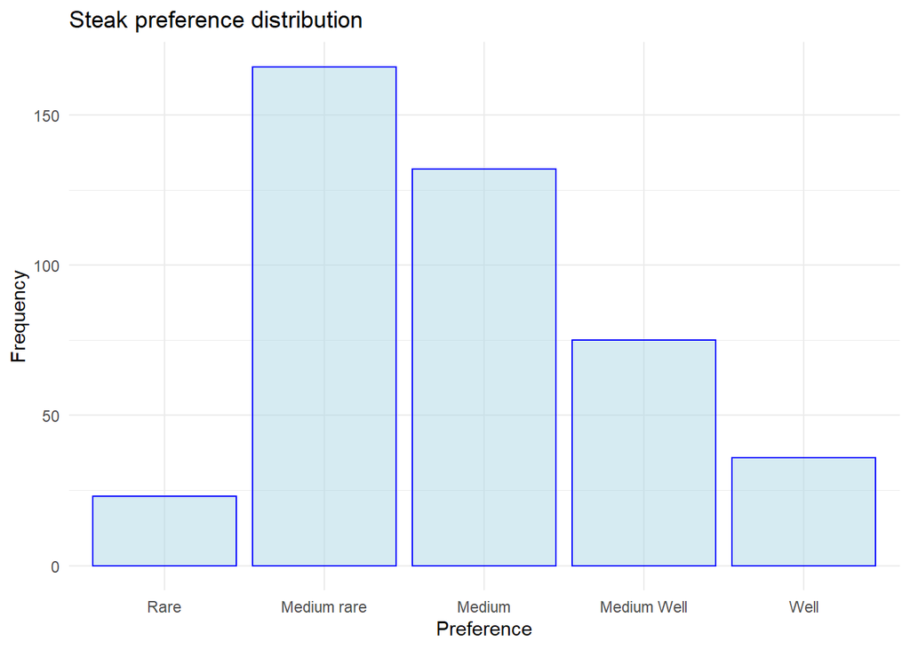

```r
ggplot(subset(d.steak, !is.na(steak_prep)), aes(steak_prep)) +
  geom_bar(color="blue", fill="lightblue", alpha=0.5) +
  xlab("Preference") + ylab("Frequency") +
  theme_minimal() + ggtitle("Steak preference distribution")
```

### 2(c)

We guess that the sign of the coefficient should be positive. Our reasoning is that the more risk-averse an individual is, the less likely he or she is to risk eating rare steak.

```r
# restrict data to steakeaters
steakeaters <- subset(
  d.steak, steak=="TRUE",
  select = c("cooking_temp", "cheat", "steak", "riskaverse", "rand_age", "yrs_ed")
)
```

```r
# compute coefficient "by hand"
y1 <- steakeaters$cooking_temp
x1 <- steakeaters$riskaverse

cov_cr <- cov(y1, x1, use="pairwise")
var_r <- var(x1, na.rm = T)

beta_1 <- cov_cr/var_r

# beta_0 <- mean(y1) - beta_1*mean(x1, na.rm=T)

beta_0 <-
  mean(
    subset(steakeaters, is.na(riskaverse)==F, select = c("cooking_temp"))$cooking_temp
  )- beta_1 * mean(x1, na.rm=T)

cat(sprintf("The intercept is %.3f\nThe coefficient is %.3f", beta_0, beta_1))
```

```
## The intercept is 134.390
## The coefficient is -0.069
```

```r
# compute coefficient by running regression
model1 <- lm(cooking_temp ~ riskaverse, data = steakeaters)

stargazer(model1, header = F, title = "Model (1)", type = "html",
          keep.stat = c("n", "rsq", "ser"), single.row = T)
```

**Model (1)**

|  | *Dependent variable:* |
| --- | --- |
|  | cooking_temp |
| riskaverse | -0.069 (0.646) |
| Constant | 134.390*** (0.465) |
| Observations | 426 |
| R<sup>2</sup> | 0.00003 |
| Residual Std. Error | 6.658 (df = 424) |
| *Note:* | p<0.1; p<0.05; p<0.01 |

### 2(d)

- It is important to include a constant in the regression model.
- Regression estimates will be biased if forced to go through the origin.
- No constant implies that preferred cooking temperature is zero when explanatory variables equal to zero, which is unrealistic.

### 2(e)

```r
model2 <- lm(cooking_temp ~ 1 + riskaverse + log(yrs_ed) + rand_age +
               I(rand_age^2) + cheat, data = steakeaters)

stargazer(model1, model2, header = F, single.row = T, type = "html",
          title = "Comparison between Model (1) and Model (2)",
          keep.stat = c("n", "rsq", "ser"))
```

**Comparison between Model (1) and Model (2)**

|  | *Dependent variable:* |  |
| --- | --- | --- |
|  | cooking_temp |  |
|  | (1) | (2) |
| riskaverse | -0.069 (0.646) | -0.124 (0.661) |
| log(yrs_ed) |  | -5.366** (2.670) |
| rand_age |  | 0.022 (0.093) |
| I(rand_age2) |  | -0.0004 (0.001) |
| cheat |  | 0.380 (0.883) |
| Constant | 134.390*** (0.465) | 149.056*** (7.432) |
| Observations | 426 | 403 |
| R<sup>2</sup> | 0.00003 | 0.018 |
| Residual Std. Error | 6.658 (df = 424) | 6.628 (df = 397) |
| *Note:* | p<0.1; p<0.05; p<0.01 |  |

```r
beta_3 <- as.numeric(coef(model2)["riskaverse"])
beta_4 <- as.numeric(coef(model2)["rand_age"])
beta_5 <- as.numeric(coef(model2)["I(rand_age^2)"])

# marginal effect of 1 additional year of education on cooking temperature
m_yrs_ed <- as.numeric(mean(steakeaters$yrs_ed, na.rm = T))
me1 <- beta_3 * (log(m_yrs_ed + 1) - log(m_yrs_ed))

# marginal effect of having cheated on a spouse on cooking temperature
me2 <- coef(model2)["cheat"]

# marginal effect of 10 additional years of age on cooking temperature
m_rand_age <- as.numeric(mean(steakeaters$rand_age, na.rm = T))
me3 <- beta_4 * 10 + beta_5 * ((m_rand_age + 10)^2 - m_rand_age^2)

cat(sprintf("Marginal effect of 1 addtional year of education is %.3f
            \nMarginal effect of having cheated on a spouse is %.3f
            \nMarginal effect of 10 additional years of age is %.3f",
            me1, me2, me3))
```

```
## Marginal effect of 1 addtional year of education is -0.008
##
## Marginal effect of having cheated on a spouse is 0.380
##
## Marginal effect of 10 additional years of age is -0.224
```

### 2(f)

```r
# create a dataframe to store mean value for each variable
mean_data <- data.frame(
  riskaverse = mean(steakeaters$riskaverse, na.rm = T),
  yrs_ed = mean(steakeaters$yrs_ed, na.rm = T),
  rand_age = mean(steakeaters$rand_age, na.rm = T),
  cheat = mean(steakeaters$cheat, na.rm = T)
)

# predict cooking temperature when all explanatory variables are set to their mean
predict(model2, newdata = mean_data)
```

```
##        1
## 134.4202
```

It is not an informative number to look at. For the dummy variables (*riskaverse* and *cheat*), it does not make sense to set them at their mean value.

### 2(g)

It is not a good idea to include both the estimated age and the categorical age variable.

- Imperfect Multicollinearity.
- It does not make sense to square a categorical variable.

### 2(h)

- Data set is not large enough to capture the true effects.
- We might fit the data with a wrong model.

### 2(i)

```r
# drop missing values
steakeaters <- steakeaters[complete.cases(steakeaters), ]

# generate predicted residuals variable
steakeaters$pred_residuals <- NA # initialize a column
steakeaters$pred_residuals <- predict(model2, steakeaters) - steakeaters$cooking_temp
```

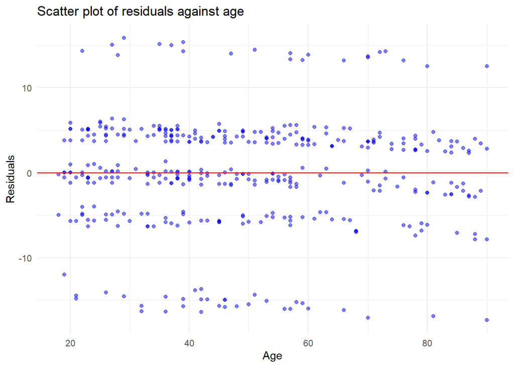

```r
ggplot(steakeaters, aes(x=rand_age, y=pred_residuals)) +
  geom_point(color="blue", alpha=0.5) +
  geom_hline(yintercept=0, color="red") +
  xlab("Age") + ylab("Residuals") +
  theme_minimal() + ggtitle("Scatter plot of residuals against age")
```

**Scatter plot of residuals against age** shows that residuals do not vary across different ages. Homoskedasticity assumption holds.

```r
set.seed(123)

df <- data.frame(
  steakeaters$pred_residuals,
  rnorm(nobs(model2), 0, sigma(model2))
)

colnames(df) <- c("Predicted Residuals", "Normal Distribution")

df <- reshape(
  df,
  direction = "long",
  varying = list(names(df)),
  v.names = "values",
  timevar = "residuals",
  times = c("Predicted Residuals", "Normal Distribution")
)
```

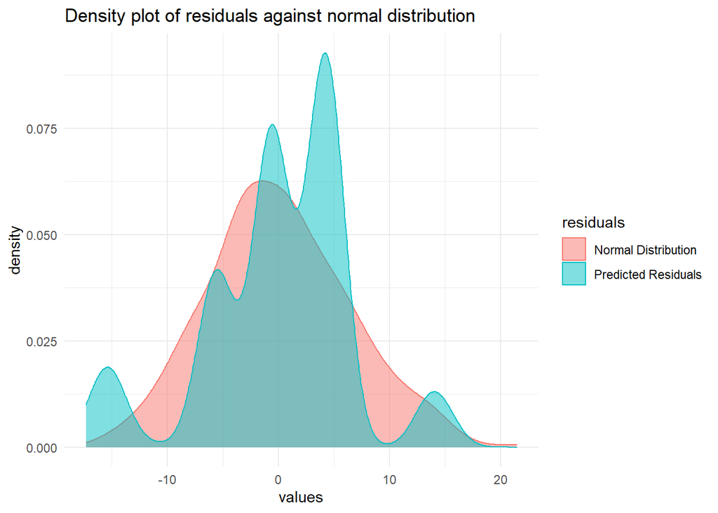

```r
ggplot(df, aes(x = values)) +
  geom_density(aes(group = residuals, color = residuals, fill = residuals), alpha = 0.5) +
  theme_minimal() + ggtitle("Density plot of residuals against normal distribution")
```